# Package `qdist`

## Truncated probability function in `R`

`R` provides probability, density, quantile and random number generator functions using a stable naming convention both for the names of the functions and in the first argument of these functions:

- probability distribution functions `pdist(q)` with `q` vector of quantiles
- density functions `ddist(x)` with `x` vector of quantiles
- quantile functions `qdist (p)` with `p` vector of probabilities.
- random number generation `rdist (n)` with `n` number of observations

where `dist` indicates the type of distribution.

As a result we have: `pnorm(q)`, `dnorm(x)`, `qnorm(p)` and `rnorm(n)` for normal distribution and similarly for all other distributions

Therefore, we use to write:

```r
pnorm(q = 8:12, mean = 10, sd = 1)
```

```
## [1] 0.02275 0.15866 0.50000 0.84134 0.97725
```

to get probability values at `8:12` from a normal distribution with parameters `mean=10` and `sd=1`.

In case we need values from a truncated distribution, as far as we know, we need to load an extra package such as `truncdist`.

```r
require("truncdist")
```

The package itself works perfectly. In fact, assuming that function `pnorm()` exists, we can get probability values from a normal distribution left truncated at `a` and right truncated at `b`, with parameters `mean = 10` and `sd = 1` by simply writing:

```r
ptrunc(q = 8:12 , spec = "norm", mean = 10 , sd = 1, a = 9, b = 11)
```

```
## [1] 0.0 0.0 0.5 1.0 1.0
```

where `a = 9` and `b = 11` respectively represent the left and the right thresholds for truncation.

Nevertheless, the above command requires a change in our programming style. We are used to have a single `R` function for each distribution: `pnorm()`, `pweibull()` etc …

We could easily write function `tpnorm()`, a truncated version for `pnorm()`, as:

```r
tpnorm <-
  function (q, mean = 0, sd = 1, L = -Inf , U = Inf, ...){
    q <- pmax(pmin(q,U),L)
    pq <- stats::pnorm(q = q, mean = mean, sd = sd, ...)
    pL <- stats::pnorm(q = L, mean = mean, sd = sd, ...)
    pU <- stats::pnorm(q = U, mean = mean, sd = sd, ...)
    p <- (pq-pL)/(pU-pL)
    p
}
```

This function clearly works:

```r
tpnorm( q = 8:12, mean = 10, sd = 1, L = 9, U = 11)
```

```
## [1] 0.0 0.0 0.5 1.0 1.0
```

but it is limited to the normal distribution. Following this approach, we would need to write a different function for each probability distribution and, we'll have to admit that all of this could become quite time consuming and not really efficient.

As an alternative approach, we decided to develope package `qdist`: a package made of four functions:

- `ptruncate()`: truncated probability distribution,
- `dtruncate()`: truncated density function
- `qtruncate()`: truncated quantile functions
- `rtruncate()`: truncated random numbers generator functions.

These functions share the same logic: they take as input a probability distribution as a character string and return the equivalent truncated distribution as a function object so that we can write:

```r
require(qdist)
tpnorm <- ptruncate("norm")
tdnorm <- dtruncate("norm")
tqnorm <- qtruncate("norm")
trnorm <- rtruncate("norm")
```

As a first detailed example, let's consider `ptruncate()` in more details applied to the normal case.

The newly generated function `tpnorm()` has the same formals as the original `pnorm()`, plus two extra parameters: `L` and `U`, respectively for lower and upper truncation thresholds set by default to `-Inf` and +`Inf`:.

```r
args(pnorm)
```

```
## function (q, mean = 0, sd = 1, lower.tail = TRUE, log.p = FALSE)
## NULL
```

```r
args(tpnorm)
```

```
## function (q, mean = 0, sd = 1, lower.tail = TRUE, log.p = FALSE,
##     L = -Inf, U = Inf)
## NULL
```

Once we have defined `tpnorm()` we can use it for generating probabilities values from not-truncated normal distributions by leaving parameters `L` and `U` set to their defaults:

```r
q <- seq(6, 14, len = 100)
p_L_U <- tpnorm(q, mean = 10, sd = 1)
```

or from any truncated normal distribution by setting values for `L` and `U`:

```r
p_L9_U11 <- tpnorm(q, mean = 10, sd = 1, L = 9, U = 11)
```

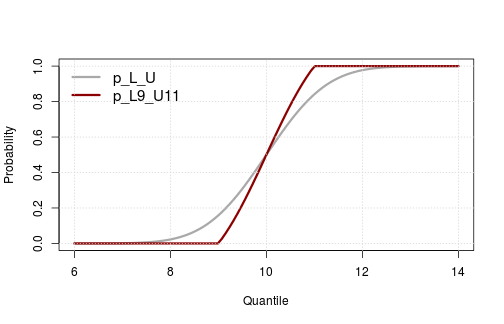

As a second example, we consider a density function for a left truncated Weibull distribution. We first generate function `tdweibull()` by using `dtruncate()`:

```r
tdweibull <- dtruncate("weibull")
```

and afterward, we can use it as:

```r
x <- qweibull(ppoints(1000), shape = 2, scale = 7)
d_L0 <- tdweibull(x, shape = 2, scale = 7)
d_L3 <- tdweibull(x, shape = 2, scale = 7, L = 3)
d_L5 <- tdweibull(x, shape = 2, scale = 7, L = 5)
d_L7 <- tdweibull(x, shape = 2, scale = 7, L = 7)
```

with the following results:

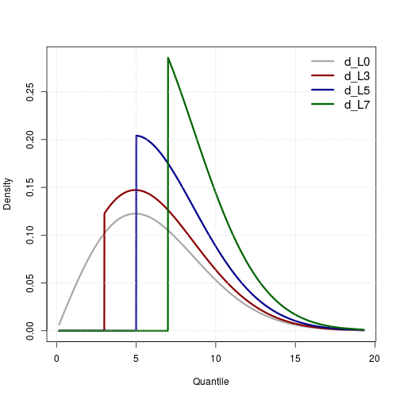

As an example of random number generator function we consider the Gumbel distribution from package `evd`:

```r
require(evd)
trgumbel <- rtruncate("gumbel")
args(trgumbel)
```

```
## function (n, loc = 0, scale = 1, L = -Inf, U = Inf)
## NULL
```

```r
rg <- trgumbel(10^4, loc = 3, scale = 2, L = 5)
```

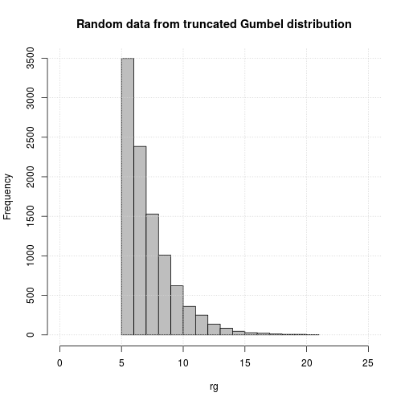

This approach works for both continuos and discrete probability functions. Let's consider the case of main quantiles generated from a Poisson distribution:

```r
tqpois <- qtruncate("pois")
tqpois(1:3/4, lambda = 100, L  = 90, U = 100)
```

```
## [1] 93 96 98
```

## The `gamma` case

The gamma case may result a bit foulty because of the check on input paramemters implemented within the body of the `gamma` set of functions. As a consequence, suppose we define a truncated quantile the gamma distribution as:

```r
tqgamma <- qtruncate("gamma")
```

When we use `tqgamma()` with parameter `rate` it works but may return a set of `warnings`

```r
tqgamma(.25, shape = 1, rate = .3)
```

[output not shown]

```
## [1] 0.9589
```

when we use the same function with parameter `scale`, it returns an error:

```r
try(tqgamma(ppoints(10), shape = 1, scale = 3))
```

[output not shown]

Note that, if we simply redifine `qgamma()` and `pgamma()` as:

```r
qgamma <- function (p, shape, rate = 1, lower.tail = TRUE, log.p = FALSE) {
  scale <-  1/rate
  .External(stats:::C_qgamma, p, shape, scale, lower.tail, log.p)
}

pgamma <- function (q, shape, rate = 1, lower.tail = TRUE, log.p = FALSE) {
  scale <-  1/rate
  .External(stats:::C_pgamma, q, shape, scale, lower.tail, log.p)
}
```

now everyting should work fine:

```r
tqgamma <- qtruncate("gamma")
tqgamma(p = .25, shape = 1, rate = 3)
```

```
## [1] 0.09589
```

## Extending the computation

Once a truncated distribution is defined, we can use it as a building block for further implementations.

Suppose we want to define a function for maximum likelihood estimate for the truncated normal distribution, we can achieve this by first defining the truncated density function for the normal distribution:

```r
tdnorm <- dtruncate("norm")
```

and, subsequently, by using `tdnorm()` within an estimator function:

```r
ltnorm = function(x, L = -Inf, U = Inf) {
  theta <- c(mean(x), sd(x))
  ml <- function(theta , x, L = -Inf, U = Inf) {
        mean <- theta[1]
        sd <- theta[2]
        ml <-  tdnorm(x = x, mean = mean, sd = sd, L = L , U = U )
        -sum(log(ml))
      }
  optim(par = theta , fn = ml, x = x, L = L , U = U)$par
}
```

As a result:

```r
trnorm <- rtruncate("norm")
x <- trnorm(n = 1000, mean = 5, sd = 2, L = 3, U = 6)
ltnorm( x = x, L = 3, U = 6)
```

```
## [1] 5.158 1.959
```

#

[output not shown]